# Motor Trends - Regression Analysis

## Summary

Analyse cars data to detect if some difference exists between gaz consumption of manual cars, or automatic ones.

For that, we’ll use the data from mtcars which containing 11 measures for 32 cars from the years 73-74.

In the following sections we’ll explain why we think that the difference between the manual and automatic transmission is statically significant. But also, we’ll see that the weight has a dramatic importance when choosing a car’s transmission regarding mpg.

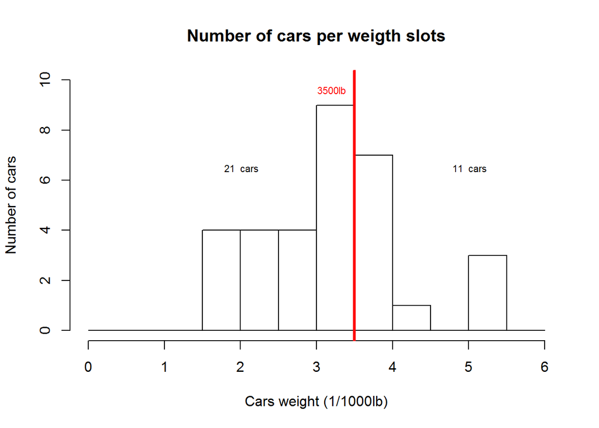

## Analysis

First of all we’re going to load the data, `mtcars`, avaible in R’s package `datasets`. Then we’ll head into to look at what it contains (and adapt the types if necessary).

```
##                    mpg cyl disp  hp drat    wt  qsec vs        am gear
## Mazda RX4         21.0   6  160 110 3.90 2.620 16.46  0    Manual    4
## Mazda RX4 Wag     21.0   6  160 110 3.90 2.875 17.02  0    Manual    4
## Datsun 710        22.8   4  108  93 3.85 2.320 18.61  1    Manual    4
## Hornet 4 Drive    21.4   6  258 110 3.08 3.215 19.44  1 Automatic    3
## Hornet Sportabout 18.7   8  360 175 3.15 3.440 17.02  0 Automatic    3
## Valiant           18.1   6  225 105 2.76 3.460 20.22  1 Automatic    3
##                   carb
## Mazda RX4            4
## Mazda RX4 Wag        4
## Datsun 710           1
## Hornet 4 Drive       1
## Hornet Sportabout    2
## Valiant              1
```

So there are 32 observations of cars and 11 measures.

We’re interested in the role playing by the transmission (`am`) in the evolution of miles/gallon consumption (`mpg`).

To see a visual interpretation of the relation between the two, a boxplot is available below.

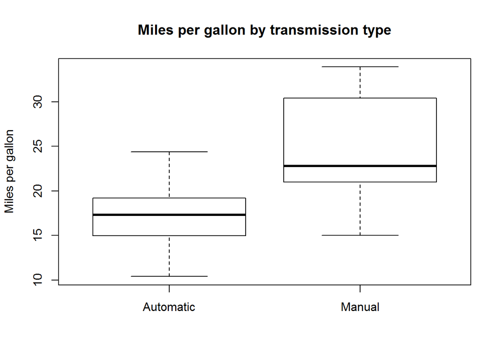

The difference between both is significant (p-value 0.0013736) and the 95% confidence interval doesn’t contains 0, and thus, at this stage, we can say that the manual cars are better than automatic cars from 3.2096842 to 11.2801944 miles per galon.

However, using the transmission alone is not enough to quantify the difference for specific cases. To see that, we can look at the prediction of mile per gallon using the single transmission independent variable in a linear regression.

So the relation between the to is rather clear, with p-value of the change being 2.850207410^{-4}. However, the variance explained is quite low, with an `R²` at 0.3597989. So something is missing in the mix.

In order to find another model explaining better the miles per gallon, we’ll use the best model selection since our dataset is quite small. For the sake of sanity, models selected by the stepwise method (forward and backward) have been ran, and they were only diverging at the third variable selecting `hp` or `qsec`. To run these selections, we’ll use the useful package `leaps`.

After playing around, `wt` is the first candidate to try out. A visual representation on how `mpg` is related to both `am` and `wt`.

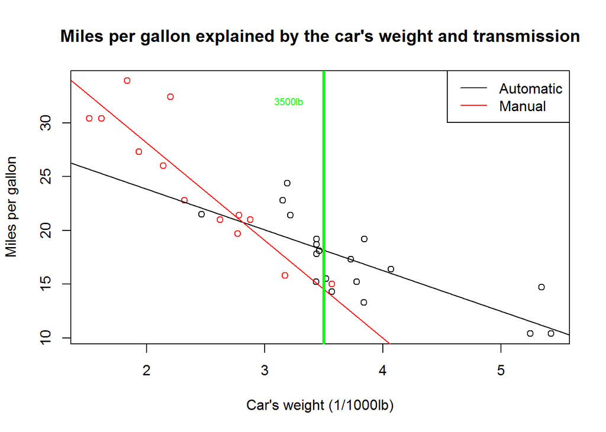

Nevertheless, the figure is more or less showing an interaction between `wt` and `am`. So, we’re going to add this interaction to the moedl and check if it’s significant.

```
##              Estimate Std. Error   t value     Pr(>|t|)
## (Intercept)  9.723053  5.8990407  1.648243 0.1108925394
## wt          -2.936531  0.6660253 -4.409038 0.0001488947
## amManual    14.079428  3.4352512  4.098515 0.0003408693
## qsec         1.016974  0.2520152  4.035366 0.0004030165
## wt:amManual -4.141376  1.1968119 -3.460340 0.0018085763
```

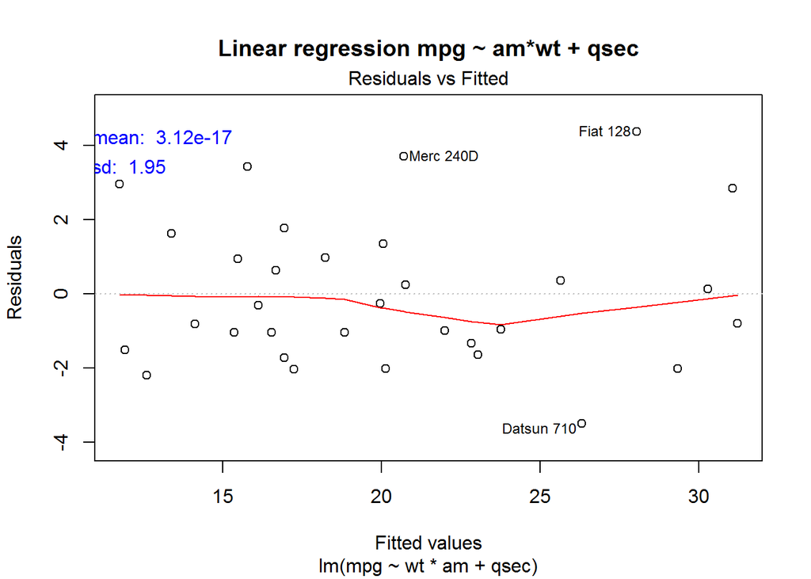

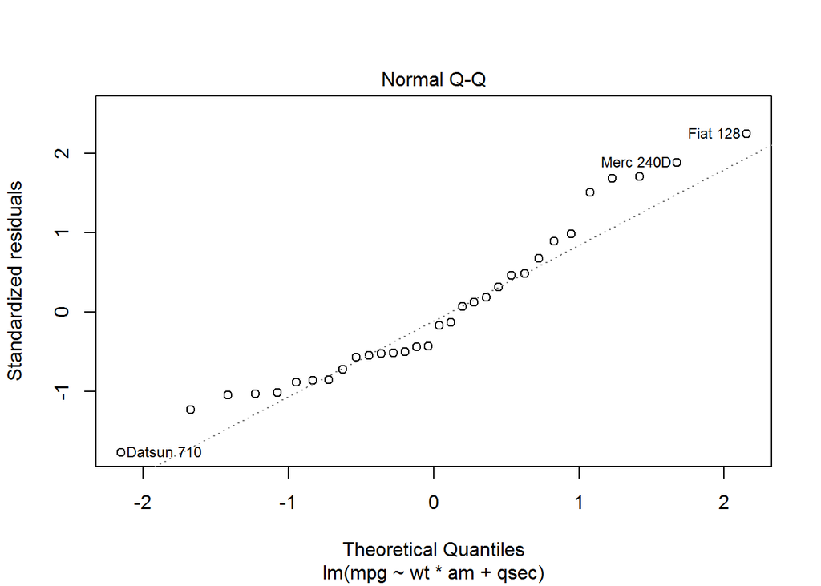

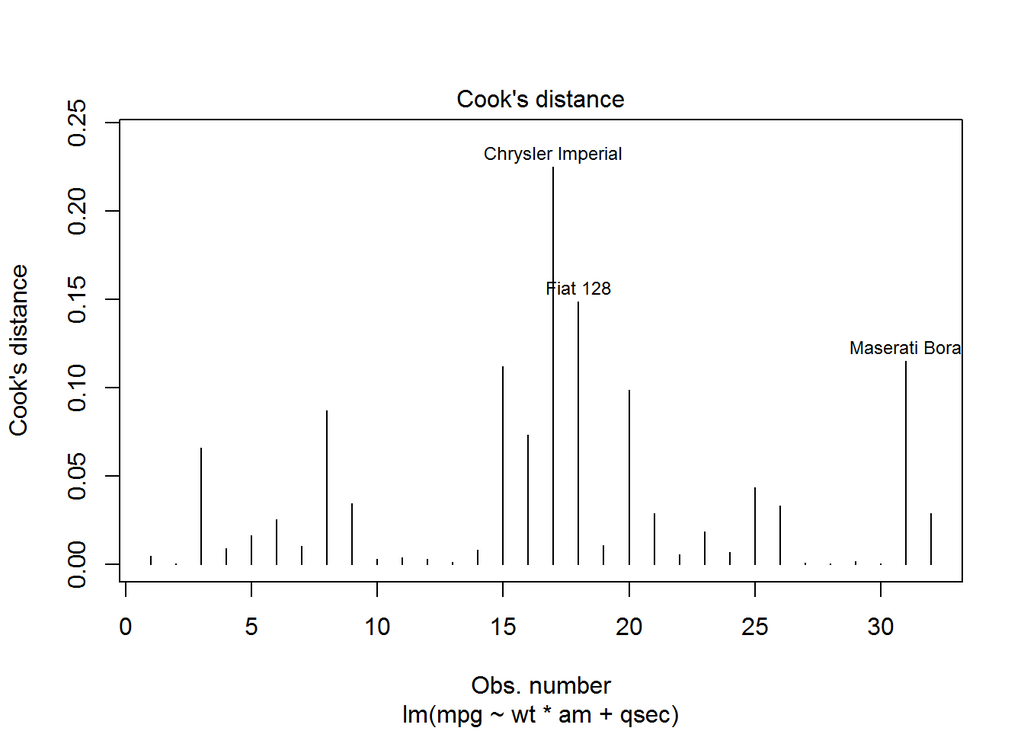

Now we can test how this new variable (interaction) in the model is significant to explain the variance, for this we can run an anova.

Sounds like it’s fair enough to include it, since the p-value is 0.0018086!

For the sake of sanity, we can have a quick look at the VIF of the models, using the `vif` function in the `car` package.

Without interaction, we have this very good VIF:

```
##       wt     qsec       am
## 2.482952 1.364339 2.541437
```

However, with the interaction we have this one:

```
##        wt        am      qsec     wt:am
##  3.030963 20.970925  1.447406 16.302453
```